# Kobe Bryant Shooting

Ryan Burge

April 27, 2016

# Kobe Bryant’s Success Against Different Opponents and Throughout His Career

```r
library(ggplot2) # Data visualization
library(readr) # CSV file I/O, e.g. the read_csv function
library(dplyr)
library(DT)
```

```r
kobe <- read.csv("D:/kobe/kobe.csv", stringsAsFactors = FALSE)
```

I want to do some quick and broad data exploration to see if Kobe is a better shooter against certain opponents.

I need to take a look at the important variable first, kobe$shot_made_flag.

```r
head(kobe$shot_made_flag, 50)
```

```
##  [1] NA  0  1  0  1  0  1 NA  1  0  0  1  1  0  0  0 NA  1  0 NA  0  0  1
## [24]  1  1  0  0  0  0  0  1  0 NA NA NA NA NA NA  1  1  0  1  1  0 NA  1
## [47]  0  1  1 NA
```

There are a lot of NAs in there, that will make this difficult so I am just going to ignore them for this analysis, I don’t think it can make a huge difference in the final analysis.

```r
team <- aggregate(kobe$shot_made_flag, list(kobe$opponent), na.rm = TRUE, mean)
team <- arrange(team, x)
head(team, 33)
```

```
##    Group.1         x
## 1      BKN 0.4000000
## 2      IND 0.4009585
## 3      NOP 0.4076655
## 4      MIL 0.4102564
## 5      BOS 0.4112388
## 6      OKC 0.4188948
## 7      WAS 0.4271457
## 8      MIA 0.4294004
## 9      CHI 0.4302326
## 10     HOU 0.4345961
## 11     ORL 0.4354305
## 12     CHA 0.4360000
## 13     NJN 0.4360190
## 14     SAS 0.4365079
```

[output cut: 19 more lines]

So, I’ve got what I need now. A smaller dataframe with just the opponents name and Kobe’s shooting percentage against them. I want to add a little extra analysis, so I am going to create a vector that lists the conferences of each opponent. There’s not an easy way to do this, so I will just do it by hand.

```r
team$conference <- c("Eastern", "Eastern", "Western", "Eastern", "Eastern" ,"Western", "Eastern", "Eastern" , "Eastern" , "Western" , "Eastern", "Eastern", "Eastern", "Eastern" , "Western" , "Eastern", "Eastern", "Western", "Western", "Eastern", "Western" , "Eastern", "Eastern", "Western", "Western", "Western", "Western" , "Western", "Western", "Western", "Western", "Western", "Eastern" )
```

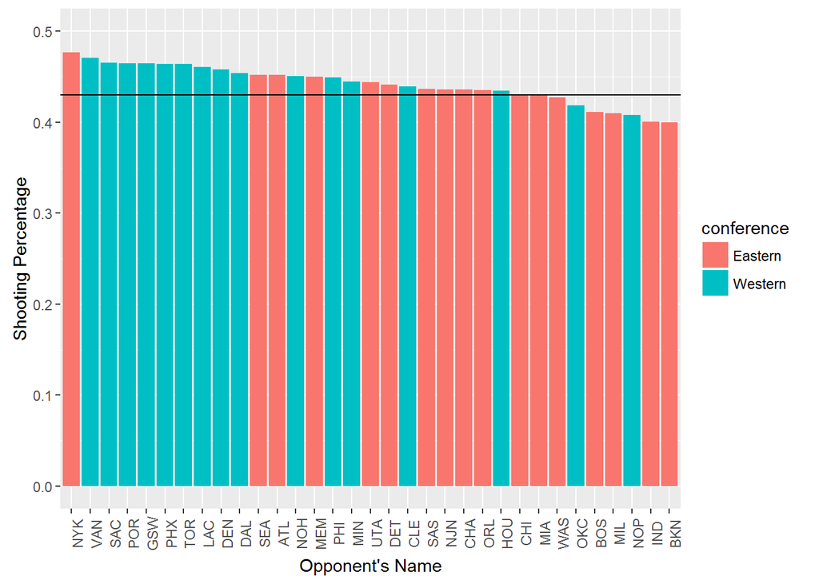

```r
ggplot(team, aes(x=reorder(Group.1, -x), y = x)) + geom_bar(aes(fill=conference),stat="identity")  + ylim(0,.5) + theme(axis.text.x = element_text(angle = 90)) + xlab("Opponent's Name") + ylab("Shooting Percentage") + geom_hline(yintercept = .43)
```

I also want to see if Kobe really declined near the end of his career. I know that he tore his Achilles and missed a lot of time. Again, I’m adding a line to indicate Kobe’s lifetime shooting percentage.

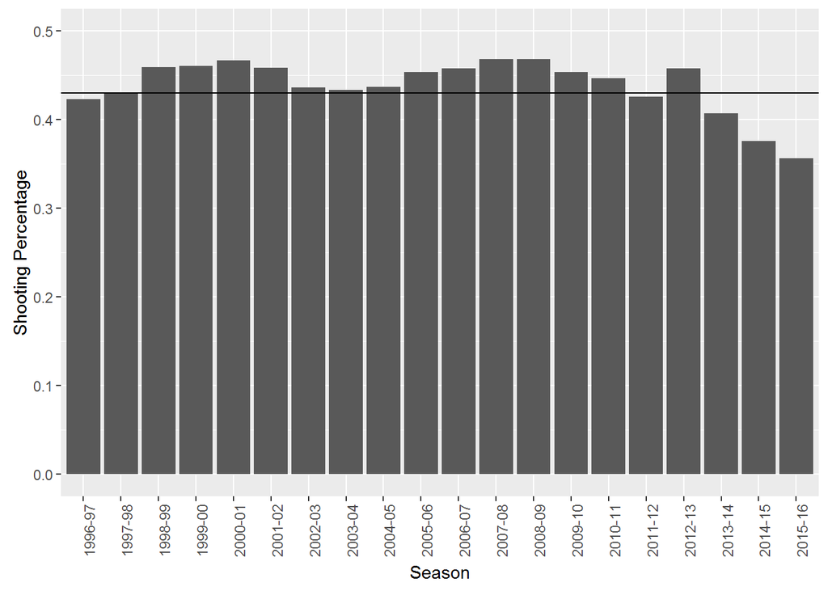

```r
season <- aggregate(kobe$shot_made_flag, list(kobe$season), na.rm = TRUE, mean)
ggplot(season, aes(x=Group.1, y = x)) + geom_bar(stat="identity")  + ylim(0,.5) + theme(axis.text.x = element_text(angle = 90, hjust = 1)) + xlab("Season") + ylab("Shooting Percentage") + geom_hline(yintercept = .43)
```

Here’s a quick data table to show that decline in a different format.

```r
datatable(season, class = 'compact')
```

|  | Group.1 | x |
| --- | --- | --- |
| 1 | 1996-97 | 0.422976501305483 |
| 2 | 1997-98 | 0.430864197530864 |
| 3 | 1998-99 | 0.458823529411765 |
| 4 | 1999-00 | 0.460365853658537 |
| 5 | 2000-01 | 0.466666666666667 |
| 6 | 2001-02 | 0.458430913348946 |
| 7 | 2002-03 | 0.436285097192225 |
| 8 | 2003-04 | 0.433260393873085 |
| 9 | 2004-05 | 0.436557231588287 |
| 10 | 2005-06 | 0.453742203742204 |

[output cut: 10 more lines]

Those last three years are pretty brutal. 40.6%, 37.6%, and 35.6%. Much lower than Kobe was used to. He knew he was in terminal decline and decided to retire.